# basic EDA

Claudio Sebastián Castillo

26 de agosto de 2022

```r
source(paste0(HOME_DIR,"/src/scripts/data_processing/process_raw_data.R"))
```

```
INFO  [2022-08-25 10:09:19] Info_message:reading dataset
INFO  [2022-08-25 10:09:19] Info_message:basic reading formating
```

```r
skimr::skim(data)
```

```
── Data Summary ────────────────────────
                           Values
Name                       data
Number of rows             8311
Number of columns          47
_______________________
Column type frequency:
  character                7
  factor                   18
  numeric                  22
________________________
Group variables            None
```

|  | skim_variable | n_missing | complete_rate | min | max | empty | n_unique | whitespace |
| --- | --- | --- | --- | --- | --- | --- | --- | --- |
| 1 | codigo_paciente | 0 | 1.00000000 | 5 | 7 | 0 | 8311 | 0 |
| 2 | fdiag_covid | 28 | 0.99663097 | 10 | 10 | 0 | 346 | 0 |
| 3 | metodo_otro | 8163 | 0.01780772 | 3 | 30 | 0 | 58 | 0 |
| 4 | fini_sintomas | 493 | 0.94068103 | 10 | 10 | 0 | 349 | 0 |
| 5 | finternacion | 28 | 0.99663097 | 10 | 10 | 0 | 342 | 0 |
| 6 | no_neumonia_cual | 8135 | 0.02117675 | 3 | 50 | 0 | 43 | 0 |
| 7 | resultado | 0 | 1.00000000 | 6 | 8 | 0 | 2 | 0 |

|  | skim_variable | n_missing | complete_rate | ordered | n_unique | top_counts |
| --- | --- | --- | --- | --- | --- | --- |
| 1 | sexo | 20 | 0.9975936 | FALSE | 2 | 1: 5174, 2: 3117 |
| 2 | neumonia | 24 | 0.9971123 | FALSE | 2 | 1: 8111, 2: 176 |
| 3 | severidad_ins | 37 | 0.9955481 | FALSE | 4 | 2: 6607, 1: 1447, 0: 144, 3: 76 |
| 4 | sat_aire_ambiente | 74 | 0.9910961 | FALSE | 2 | 1: 6471, 2: 1766 |
| 5 | progr_image_rad | 28 | 0.9966310 | FALSE | 2 | 2: 5635, 1: 2648 |
| 6 | oxigeno_supl | 28 | 0.9966310 | FALSE | 2 | 1: 6229, 2: 2054 |
| 7 | vni | 28 | 0.9966310 | FALSE | 2 | 2: 7554, 1: 729 |
| 8 | uti | 28 | 0.9966310 | FALSE | 2 | 2: 7746, 1: 537 |
| 9 | arm | 28 | 0.9966310 | FALSE | 2 | 2: 8232, 1: 51 |
| 10 | inotropicos | 28 | 0.9966310 | FALSE | 2 | 2: 8267, 1: 16 |

[output cut: 8 more lines]

|  | skim_variable | n_missing | complete_rate | mean | sd | p0 | p25 | p50 | p75 | p100 | hist |
| --- | --- | --- | --- | --- | --- | --- | --- | --- | --- | --- | --- |
| 1 | embarazo | 5196 | 0.3748045 | 1.997432e+00 | 5.062060e-02 | 1.0 | 2.0 | 2.0 | 2.0 | 2.0 | ▁▁▁▁▇ |
| 2 | edad | 0 | 1.0000000 | 5.283371e+01 | 1.437961e+01 | 0.0 | 43.0 | 53.0 | 63.0 | 96.0 | ▁▃▇▆▁ |
| 3 | peso | 26 | 0.9968716 | 8.939759e+01 | 2.013401e+01 | 0.0 | 76.0 | 87.0 | 100.0 | 412.0 | ▆▇▁▁▁ |
| 4 | altura | 35 | 0.9957887 | 1.600011e+02 | 3.799921e+01 | 0.0 | 161.0 | 169.0 | 174.0 | 198.0 | ▁▁▁▁▇ |
| 5 | imc | 458 | 0.9448923 | 3.153730e+01 | 6.481950e+00 | 11.4 | 27.1 | 30.5 | 34.6 | 99.9 | ▆▇▁▁▁ |
| 6 | metodo_diag | 26 | 0.9968716 | 2.125528e+00 | 1.013874e+00 | 1.0 | 1.0 | 3.0 | 3.0 | 4.0 | ▆▁▁▇▁ |
| 7 | igg | 27 | 0.9967513 | 2.936866e+00 | 3.130972e-01 | 1.0 | 3.0 | 3.0 | 3.0 | 3.0 | ▁▁▁▁▇ |
| 8 | igm | 27 | 0.9967513 | 2.946523e+00 | 2.769485e-01 | 1.0 | 3.0 | 3.0 | 3.0 | 3.0 | ▁▁▁▁▇ |
| 9 | ig_total | 27 | 0.9967513 | 2.921898e+00 | 3.739798e-01 | 1.0 | 3.0 | 3.0 | 3.0 | 3.0 | ▁▁▁▁▇ |
| 10 | frecuencia_respiratoria | 581 | 0.9300926 | 2.300375e+01 | 4.767066e+00 | 2.0 | 20.0 | 22.0 | 25.0 | 52.0 | ▁▇▅▁▁ |

[output cut: 12 more lines]

# Definición del problema

El dataset contiene información biomédica de pacientes y variable dependiente binaria “muerte/no_muerte”. Estamos ante un problema de clasificación binaria.

La métrica para evaluar la performance de nuestro modelo será “precisiónn” (true positive/predicted positive) y “exhaustividad” (true positive / all positive cases).

# Visión General del dataset

En las tablas precedentes surge información exploratoria importante.

Tenemos variables de distintos tipos. El grupo de variables tipo *character* contiene algunas de alta cardinalidad así que podríamos evitar su empleo o bien discretizar, algunas con alto porcentaje de valores faltantes.

Hay también 18 variables factor, en estado aparentemente saludable.

# Valores faltantes

De las tablas precedentes podemos ver que existen muchas variables con valores faltantes (e.g. caso extremo *embarazo* con 63%). Esto podría ser una dificultad considerando que una gran mayoría de modelos en ML no admiten valores faltantes, pero en nuestro caso, dado que trabajaremos con el algoritmo *gradient boosting of decisión tree* (implementado en ligthgbm), esta conformación del dataset no representa un obstáculo.

Sin perjuicio de ello buscaremos formas de mejorar esta condición a través de distintos métodos (vía imputación o exclusión).

# Variable dependiente

```r
table(data$resultado)
```

[output not shown]

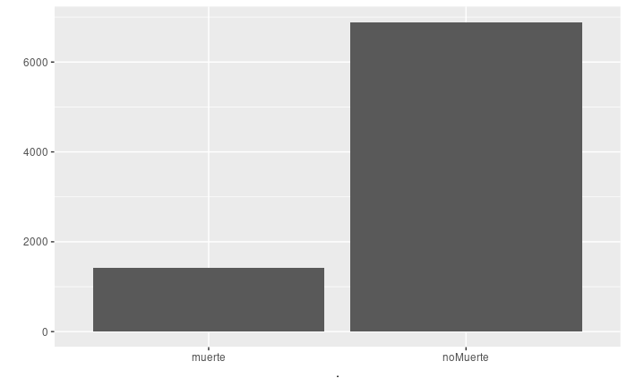

```r
data$resultado %>% qplot()
```

La mortalidad que surge del dataset es de 0.1708579. Nuestro modelo de *nula precisión*, es decir si clasificaremos a todos los nuevos casos como muerte tendríamos el valor precedente como linea_base.